# He-Man and The Master of the Universe: Twitter Analysis

Rumors of Mattel's plans to reboot the iconic He-Man and The Masters of the Universe (MOTU) toy land and media have been swirling for quite a while. In 2020, Mattel launched a retro toyline called Masters of the Universe Origins as a Walmart exclusive. As of January 2021, MOTU Origins became available at other retailers like Amazon and Target. For the most part the reception of these toys has been luke-warm. There are die-hard MOTU fans who have been eating this toyline up with a spoon, but the dozens of Skeletors hanging on the pegs is hard to ignore. The main audience for these toys, children, seem largely uninterested. In anticipation of two Netflix exclusive animated series, Mattel launched two new MOTU toy lines. Masterverse is a more modern collector's line that features the character designs of Netflix's Masters of the Universe Revelation. He-Man And The Masters Of The Universe Action Figures features re-designed versions of the characters as they appear in the Netflix series of the same name. These action figures are chunky, cartoony, and less detailed to appeal to children, four years-old and older (and a $10 to appeal to parents). It's too early to say how these more recent toy lines are doing, but needless to say that the popular reception of the Netflix series can give an indication about how much buzz there is about this property. The analysis below focuses on the redesigned "For Children" Netflix sereies He-Man And The Masters Of The Universe which was released on Thursday, September 16, 2021.

This analysis measures the engagement and sentiment of tweets that featured the hashtag "#HeManandtheMastersoftheUniverse". The tweets were downloaded on Monday, September 20, 2021, in effort to get the hot take from fans and audience members. In terms of engagement, these tweets recieved 6.6 likes per tweet, 1.0 retweets, and 0.6 replies.

```
+---------------------+---------------+
| ENGAGEMENT MEASURE  | VALUE         |
=======================================
| Likes               | 6.6 per tweet |
+---------------------+---------------+
| Retweets            | 1.0 per tweet |
+---------------------+---------------+
| Replies             | 0.6 per tweet |
+---------------------+---------------+
```

```
+--------------------+-------+---------+
| SENTIMENT MEASURE  | MEAN  | STD DEV |
========================================
| Polarity           | 0.147 | 0.257   |
+--------------------+-------+---------+
| Subjectivity       | 0.332 | 0.326   |
+--------------------+-------+---------+
```

On a personal note, I am a big fan of Masters of the Universe. I thought that both of the animated series had a lot of things to like about them. I thought Revelation was mostly unnecessary. I hope that Mattel can keep producing some of the collector lines even if they are not available at mass retail. Who knows? We might get a live action movie someday. MOTU has the potential to be a great action fantasy franchise.

```python
# Load Packages

import pandas as pd
import numpy as np
import seaborn as sns
import matplotlib.pyplot as plt
import json
```

```python
df = pd.read_json('HeMan_Sept2021.json', lines = True)

pd.set_option('display.max_columns', None)

print("Data Shape:",df.shape)
df.head()
```

```
Data Shape: (429, 36)
```

|  | id | conversation_id | created_at | date | time | timezone | user_id | username | name | place | tweet | language | mentions | urls | photos | replies_count | retweets_count | likes_count | hashtags | cashtags | link | retweet | quote_url | video | thumbnail | near | geo | source | user_rt_id | … |
| --- | --- | --- | --- | --- | --- | --- | --- | --- | --- | --- | --- | --- | --- | --- | --- | --- | --- | --- | --- | --- | --- | --- | --- | --- | --- | --- | --- | --- | --- | --- |
| 0 | 1439842845221801984 | 1439842845221801984 | 2021-09-19 23:44:19 Pacific Daylight Time | 2021-09-19 | 23:44:19 | -700 | 2534608675 | wheeljack83 | Jeffrey Harris |  | For @RogerCraigSmith , did Trap Jaw ever get h... | en | [{'screen_name': 'rogercraigsmith', 'name': 'r... | [] | [https://pbs.twimg.com/media/E_tZVYwUYAE8SL1.jpg] | 0 | 0 | 1 | [netflix, hemanandthemastersoftheuniverse] | [] | https://twitter.com/Wheeljack83/status/1439842... | False |  | 1 | https://pbs.twimg.com/media/E_tZVYwUYAE8SL1.jpg |  |  |  |  | … |
| 1 | 1439838151443423232 | 1439838151443423232 | 2021-09-19 23:25:40 Pacific Daylight Time | 2021-09-19 | 23:25:40 | -700 | 1369390053391269889 | frrrrnando | nando |  | todos os outros guerreiros de grayskull são me... | pt | [] | [] | [] | 0 | 0 | 0 | [hemanandthemastersoftheuniverse] | [] | https://twitter.com/frrrrnando/status/14398381... | False |  | 0 |  |  |  |  |  | … |
| 2 | 1439833221861019659 | 1439833221861019648 | 2021-09-19 23:06:05 Pacific Daylight Time | 2021-09-19 | 23:06:05 | -700 | 174661447 | tkoppe22 | Koppe22☢️™️ |  | #HeManandtheMastersoftheUniverse On Netflix. ... | en | [] | [] | [] | 0 | 0 | 0 | [hemanandthemastersoftheuniverse] | [] | https://twitter.com/TKoppe22/status/1439833221... | False |  | 0 |  |  |  |  |  | … |
| 3 | 1439822660108619778 | 1439822660108619776 | 2021-09-19 22:24:07 Pacific Daylight Time | 2021-09-19 | 22:24:07 | -700 | 338828258 | nickrodriguez00 | Nick Rodriguez |  | Don’t think I haven’t noticed the cloth sim in... | en | [] | [] | [] | 0 | 0 | 0 | [hemanandthemastersoftheuniverse] | [] | https://twitter.com/NickRodriguez00/status/143... | False |  | 0 |  |  |  |  |  | … |
| 4 | 1439820941513666562 | 1439820941513666560 | 2021-09-19 22:17:17 Pacific Daylight Time | 2021-09-19 | 22:17:17 | -700 | 2751766191 | dk_hennessy | Daniel Hennessy |  | This is great. The writer is reviewing He-Man ... | en | [] | [https://www.moneycontrol.com/news/trends/ente... | [] | 0 | 1 | 1 | [hemanandthemastersoftheuniverse, mastersofthe... | [] | https://twitter.com/DK_Hennessy/status/1439820... | False |  | 0 |  |  |  |  |  | … |

```python
# Create a new dataframes to subset the data by relavant attributes
tweetsRefined = pd.DataFrame(df['id'])

# Add the relevant columns
tweetsRefined.insert(1,"Date", df['date'])
tweetsRefined.insert(2,"Time", df['time'])
tweetsRefined.insert(3,"Language", df['language'])
tweetsRefined.insert(4,"Replies", df['replies_count'])
tweetsRefined.insert(5,"Likes", df['likes_count'])
tweetsRefined.insert(6,"Retweets", df['retweets_count'])
tweetsRefined.insert(7,"Tweet", df['tweet'])

# Preview the refined dataframe
tweetsRefined
```

|  | id | Date | Time | Language | Replies | Likes | Retweets | Tweet |
| --- | --- | --- | --- | --- | --- | --- | --- | --- |
| 0 | 1439842845221801984 | 2021-09-19 | 23:44:19 | en | 0 | 1 | 0 | For @RogerCraigSmith , did Trap Jaw ever get h... |
| 1 | 1439838151443423232 | 2021-09-19 | 23:25:40 | pt | 0 | 0 | 0 | todos os outros guerreiros de grayskull são me... |
| 2 | 1439833221861019659 | 2021-09-19 | 23:06:05 | en | 0 | 0 | 0 | #HeManandtheMastersoftheUniverse On Netflix. ... |
| 3 | 1439822660108619778 | 2021-09-19 | 22:24:07 | en | 0 | 0 | 0 | Don’t think I haven’t noticed the cloth sim in... |
| 4 | 1439820941513666562 | 2021-09-19 | 22:17:17 | en | 0 | 1 | 1 | This is great. The writer is reviewing He-Man ... |
| ... | ... | ... | ... | ... | ... | ... | ... | ... |
| 424 | 1433470399661154308 | 2021-09-02 | 09:42:30 | en | 0 | 1 | 0 | Faker #faker #mastersoftheuniverse #motu #hema... |
| 425 | 1433466005355831313 | 2021-09-02 | 09:25:02 | en | 1 | 5 | 1 | That’s one heck of a explosiony He-Man transfo... |
| 426 | 1433401319755329542 | 2021-09-02 | 05:08:00 | en | 0 | 0 | 0 | BUSTO DE SKELETOR MASTER OF THE UNIVERSE http... |
| 427 | 1433350079729995777 | 2021-09-02 | 01:44:24 | en | 0 | 0 | 0 | Skeletor. I bought the figure a month ago. #sk... |
| 428 | 1433320215916564481 | 2021-09-01 | 23:45:43 | fr | 0 | 5 | 0 | Et si on ressortait le Dorothée Magazine aujou... |

429 rows × 8 columns

```python
replies = sum(tweetsRefined['Replies'])
likes = sum(tweetsRefined['Likes'])
retweets = sum(tweetsRefined['Retweets'])

print('Replies:', replies)
print('Likes:', likes)
print('Retweets', retweets)
```

```
Replies: 271
Likes: 2847
Retweets 446
```

```python
# Import stopwords
import nltk
from nltk.corpus import stopwords

# Import textblob
from textblob import Word, TextBlob

nltk.download('stopwords')
nltk.download('wordnet')
stop_words = stopwords.words('english')
custom_stopwords = ['RT', '#heman', '#HeMan', '#motu', '#MastersoftheUniverse', '#HeManandtheMastersoftheUnivers']
```

```python
# Create a function to clean each tweet
def preprocess_tweets(tweet, custom_stopwords):
    preprocessed_tweet = tweet
    preprocessed_tweet.replace('[^\w\s]','')
    preprocessed_tweet = " ".join(word for word in preprocessed_tweet.split() if word not in stop_words)
    preprocessed_tweet = " ".join(word for word in preprocessed_tweet.split() if word not in custom_stopwords)
    preprocessed_tweet = " ".join(Word(word).lemmatize() for word in preprocessed_tweet.split())
    return(preprocessed_tweet)

tweetsRefined['Processed Tweet'] = tweetsRefined['Tweet'].apply(lambda x: preprocess_tweets(x, custom_stopwords))
tweetsRefined.head()
```

|  | id | Date | Time | Language | Replies | Likes | Retweets | Tweet | Processed Tweet |
| --- | --- | --- | --- | --- | --- | --- | --- | --- | --- |
| 0 | 1439842845221801984 | 2021-09-19 | 23:44:19 | en | 0 | 1 | 0 | For @RogerCraigSmith , did Trap Jaw ever get h... | For @RogerCraigSmith , Trap Jaw ever get sandw... |
| 1 | 1439838151443423232 | 2021-09-19 | 23:25:40 | pt | 0 | 0 | 0 | todos os outros guerreiros de grayskull são me... | todos o outros guerreiros de grayskull são mel... |
| 2 | 1439833221861019659 | 2021-09-19 | 23:06:05 | en | 0 | 0 | 0 | #HeManandtheMastersoftheUniverse On Netflix. ... | #HeManandtheMastersoftheUniverse On Netflix. T... |
| 3 | 1439822660108619778 | 2021-09-19 | 22:24:07 | en | 0 | 0 | 0 | Don’t think I haven’t noticed the cloth sim in... | Don’t think I haven’t noticed cloth sim #HeMan... |
| 4 | 1439820941513666562 | 2021-09-19 | 22:17:17 | en | 0 | 1 | 1 | This is great. The writer is reviewing He-Man ... | This great. The writer reviewing He-Man &amp; ... |

```python
# Calculate sentiment
tweetsRefined['Polarity'] = tweetsRefined['Processed Tweet'].apply(lambda x: TextBlob(x).sentiment[0])
tweetsRefined['Subjectivity'] = tweetsRefined['Processed Tweet'].apply(lambda x: TextBlob(x).sentiment[1])

# Display descriptive statistics Sentiment Measurements
print('Polarity Statistics')
print(tweetsRefined['Polarity'].describe())
print('________________________________')
print('Subjectivity Statistic')
print(tweetsRefined['Subjectivity'].describe())
```

```
Polarity Statistics
count    429.000000
mean       0.147316
std        0.256697
min       -1.000000
25%        0.000000
50%        0.000000
75%        0.278788
max        1.000000
Name: Polarity, dtype: float64
________________________________
Subjectivity Statistic
count    429.000000
mean       0.331598
std        0.326017
min        0.000000
25%        0.000000
50%        0.352273
75%        0.583333
max        1.000000
Name: Subjectivity, dtype: float64
```

```python
# Create a dataframe for the 10 tweet moving average of polarity values
tweetMovAvg = tweetsRefined[['Date', 'Polarity']]
tweetMovAvg = tweetMovAvg.sort_values(by='Date', ascending=True)
tweetMovAvg['Moving Avg Polarity'] = tweetMovAvg.Polarity.rolling(10, min_periods=3).mean()

tweetMovAvg
```

|  | Date | Polarity | Moving Avg Polarity |
| --- | --- | --- | --- |
| 428 | 2021-09-01 | 0.000000 | NaN |
| 420 | 2021-09-02 | 0.000000 | NaN |
| 421 | 2021-09-02 | 0.500000 | 0.166667 |
| 422 | 2021-09-02 | 0.000000 | 0.125000 |
| 427 | 2021-09-02 | -1.000000 | -0.100000 |
| ... | ... | ... | ... |
| 53 | 2021-09-19 | 0.437500 | 0.143759 |
| 54 | 2021-09-19 | 0.178571 | 0.136617 |
| 55 | 2021-09-19 | 0.000000 | 0.086617 |
| 47 | 2021-09-19 | 0.136364 | 0.100253 |
| 0 | 2021-09-19 | 0.000000 | 0.100253 |

429 rows × 3 columns

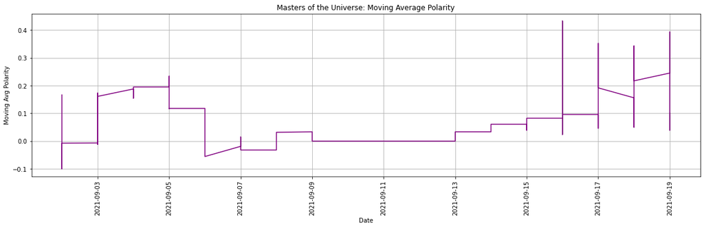

```python
# Import Matplotlib
import matplotlib.pyplot as plt

# Create a visualization for the 10-tweet moving average
fig, ax = plt.subplots(figsize=(20, 5))
ax.plot(tweetMovAvg['Date'], tweetMovAvg['Moving Avg Polarity'], color='purple')
plt.xticks(rotation = 90)


ax.set(xlabel='Date', ylabel='Moving Avg Polarity',
       title='Masters of the Universe: Moving Average Polarity')
ax.grid()

fig.savefig("heman_Sept2021.png")
plt.show()
```

```python
# Drill down by separating 'negative' tweets from 'positive' (Also eliminating neutral)
tweetsRefinedPOS = tweetsRefined[tweetsRefined['Polarity'] > 0]
tweetsRefinedNEG = tweetsRefined[tweetsRefined['Polarity'] < 0]

print("\nNumber of positive tweets: ", len(tweetsRefinedPOS))
print("\nNumber of negative tweets: ", len(tweetsRefinedNEG))
```

```
Number of positive tweets:  210

Number of negative tweets:  27
```

```python
# Preview the data sorted by Likes
tweetsEngagedPOS = tweetsRefinedPOS.sort_values('Likes', ascending=False)

tweetsEngagedPOS.head(5)
```

|  | id | Date | Time | Language | Replies | Likes | Retweets | Tweet | Processed Tweet | Polarity | Subjectivity |
| --- | --- | --- | --- | --- | --- | --- | --- | --- | --- | --- | --- |
| 253 | 1438681069998411779 | 2021-09-16 | 18:47:51 | en | 11 | 314 | 30 | What an AMAZING DAY! Took my breath away! #HeM... | What AMAZING DAY! Took breath away! #HeManandt... | 0.347917 | 0.725000 |
| 292 | 1438583811688837124 | 2021-09-16 | 12:21:22 | en | 24 | 194 | 37 | He-man and the Masters of the Universe, the se... | He-man Masters Universe, second 2 new He-Man s... | 0.106534 | 0.227273 |
| 321 | 1438488870862180358 | 2021-09-16 | 06:04:07 | en | 5 | 73 | 6 | @bryanQmiller @amandadeibert This morning my 4... | @bryanQmiller @amandadeibert This morning 4 ye... | 0.118182 | 0.327273 |
| 423 | 1433545991697821748 | 2021-09-02 | 14:42:53 | en | 8 | 63 | 10 | Okay my friends... who needs a little afternoo... | Okay friends... need little afternoon pick-up?... | 0.433594 | 0.687500 |
| 160 | 1439043978700197891 | 2021-09-17 | 18:49:55 | en | 3 | 59 | 10 | Now this is what I call bring back an old frie... | Now I call bring back old friend GOOD way (try... | 0.280000 | 0.490000 |

```python
# Preview the data sorted by Likes
tweetsEngagedNEG = tweetsRefinedNEG.sort_values('Likes', ascending=False)

tweetsEngagedNEG.head(5)
```

|  | id | Date | Time | Language | Replies | Likes | Retweets | Tweet | Processed Tweet | Polarity | Subjectivity |
| --- | --- | --- | --- | --- | --- | --- | --- | --- | --- | --- | --- |
| 402 | 1434507637161332737 | 2021-09-05 | 06:24:07 | en | 4 | 133 | 34 | The most powerful man in the universe, He-Man,... | The powerful man universe, He-Man, go evil for... | -0.212500 | 0.758333 |
| 268 | 1438665200304070663 | 2021-09-16 | 17:44:47 | es | 0 | 43 | 11 | Si aparecerá en SpiderMan 3! Llego el HeMan en... | Si aparecerá en SpiderMan 3! Llego el HeMan en... | -0.500000 | 1.000000 |
| 166 | 1439019087749861378 | 2021-09-17 | 17:11:00 | en | 2 | 23 | 8 | I don't know what's funnier; that they actuall... | I know what's funnier; actually aknowledge lon... | -0.016667 | 0.188889 |
| 322 | 1438480602152509444 | 2021-09-16 | 05:31:15 | en | 3 | 13 | 2 | Finally got my #3dprinted #battlecat from #He... | Finally got #3dprinted #battlecat mounted offi... | -0.045000 | 0.565000 |
| 154 | 1439057434530783234 | 2021-09-17 | 19:43:23 | en | 0 | 3 | 0 | Laying on the couch, drinking a beer with my b... | Laying couch, drinking beer belly hanging ever... | -0.054167 | 0.183333 |

```python
testX = df.loc[df['id'] == 1438583811688837124]
testX['link']
```

```
292    https://twitter.com/kharyrandolph/status/14385...
Name: link, dtype: object
```